# numpy ndarray详解

陈水平

2016年12月16日

## 前言

如果没有**numpy**，Python内部只能用`list`或`array`来表示矩阵。假如用list来表示`[1,2,3]`，由于`list`的元素可以是任何对象，因此`list`中所保存的是对象的指针，这样就需要有3个指针和三个整数对象，比较浪费内存和CPU计算时间。Python的`array`和`list`不同，它直接保存数值，和C语言的一维数组比较类似，但是不支持多维，表达形式很简陋，写科学计算的算法很难受。**numpy**弥补了这些不足，核心贡献就是提供了`ndarray`这个存储单一数据类型的多维数组结构，实现上采用预编译好的C语言代码，性能上的表现十分不错。

## ndarray内存结构

使用下面的代码可以生成本文讲解的`ndarray`案例：

```python
from numpy import np

a = np.array([[0,1,2],[3,4,5],[6,7,8]], dtype=np.float32)
```

我们来看一下ndarray如何在内存中储存的：关于数组的描述信息保存在一个数据结构中，这个结构引用两个对象，一块用于保存数据的存储区域和一个用于描述元素类型的dtype对象。

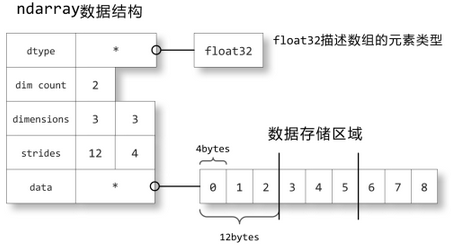

数据存储区域保存着数组中所有元素的二进制数据，dtype对象则知道如何将元素的二进制数据转换为可用的值。数组的维数、大小等信息都保存在ndarray数组对象的数据结构中。

strides中保存的是当每个轴的下标增加1时，数据存储区中的指针所增加的字节数。例如图中的strides为12,4，即第0轴的下标增加1时，数据的地址增加12个字节：即a[1,0]的地址比a[0,0]的地址要高12个字节，正好是3个单精度浮点数的总字节数；第1轴下标增加1时，数据的地址增加4个字节，正好是单精度浮点数的字节数。

## Structured Array

由于**numpy**只支持单一数据类型，对于常见的表格型数据，我们需要通过**numpy**提供的Structrued Array机制自定义`dtype`。

**numpy**支持的类型包括：

- b1, i1, i2, i4, i8, u1, u2, u4, u8, f2, f4, f8, c8, c16, a (representing bytes, ints, unsigned ints, floats, complex and fixed length strings of specified byte lengths)
- int8,…,uint8,…,float16, float32, float64, complex64, complex128 (this time with bit sizes)

定义结构化数组有四种方式：1) string, 2) tuple, 3) list, or 4) dictionary。本文推荐使用后两种方式。

```python
import numpy as np

# list方式：a list of tuples. Each tuple has 2 or 3 elements specifying: 1) The name of the field (‘’ is permitted), 2) the type of the field, and 3) the shape (optional)
persontype = [('name', 'S32'), ('age', 'i'), ('weight', 'f')]

# dict方式：需要指定的键值有names和formats
persontype = np.dtype({
        'names': ['name', 'age', 'weight'],
        'formats': ['S32', 'i', 'f']
    })
a = np.array([("Zhang", 32, 75.5), ("Wang", 24, 65.2)], dtype=persontype)
```

## 创建ndarray

共有三类基本方法：一是从Python内置的array-like数据结构转化得到；二是利用**numpy**提供的创建函数直接生成；三是使用`genfromtxt()`方法生成。

```python
# -*- coding: utf-8 -*-
import numpy as np

# 从python的list转换
x = np.array([[1,2.0],[0,0],(1+1j,3.)])


np.zeros((2, 3))
np.arange(2, 3, 0.1) # start, end, step
np.linspace(1., 4., 6) # start, end, num
np.indices((3, 3)) # 返回一个array，元素0是行下标，元素1是列下标；行下标为一个3*3二维array，对应3*3矩阵的行下标；列下标为一个3*3二维array，对应3*3矩阵的列下标


ndtype=[('a',int), ('b', float), ('c', int)]
names = ["A", "B", "C"]
np.genfromtxt("file_name.txt",
  delimiter=",",
  names=names,
  dtype=ndtype,
  autostrip=True,
  comments="#",
  skip_header=3,
  skip_footer=5,
  usecols=(0, -1))


# ndarray to list
a = np.array([[1, 2], [3, 4]])
a.tolist()
```

## 索引

`ndarray`索引的基本使用方法示例如下；

```python
x = np.arange(10)
x.shape = (2,5)
x[0][2]
x[:,0:5:2]
```

> 以下内容总结自Numpy官方文档[Numpy basics](http://docs.scipy.org/doc/numpy/user/quickstart.html)

关于`ndarray`的索引方式，有以下几个重点需要记住：

- 虽然`x[0,2] = x[0][2]`，但是前者效率比后者高，因为后者在应用第一个索引后需要先创建一个temporary array，然后再应用第二个索引，最后找到目标值。
- 分片操作不会引发copy操作，而是创建原ndarray的view；他们所指向的内存是同一片区域，无论是修改原ndarray还是修改view，都会同时改变二者的值。
- index array和boolean index返回的是copy，不是view。

关于上面列举的**分片操作不会引发copy操作**，我们来进一步探讨一下。先看一下**numpy**的例子：

```python
import numpy as np
a = np.arange(10)
a.shape = (2,5)
print "input a:", a

b = a[0, ]
print "copy b:", b

b[1] = -1
print "modify b:", b
print "final a:", a
```

```
## input a: [[0 1 2 3 4]
##  [5 6 7 8 9]]
## copy b: [0 1 2 3 4]
## modify b: [ 0 -1  2  3  4]
## final a: [[ 0 -1  2  3  4]
##  [ 5  6  7  8  9]]
```

再来看一下R的例子：

```r
a <- matrix(0:9, nrow=2, byrow=TRUE)
a
```

```
##      [,1] [,2] [,3] [,4] [,5]
## [1,]    0    1    2    3    4
## [2,]    5    6    7    8    9
```

```r
b <- a[1,]
b[2] <- -1
b
```

```
## [1]  0 -1  2  3  4
```

```r
a
```

```
##      [,1] [,2] [,3] [,4] [,5]
## [1,]    0    1    2    3    4
## [2,]    5    6    7    8    9
```

可以看到numpy和R在矩阵的分片操作有不同的设计理念：在R里分片操作会引起数据的复制，在numpy里不会。事实上，R的设计理念很多时候可以用一句话来概括：copy on modify，一旦对数据有修改就会引起内存上的复制操作，这个操作要花不少时间，因此经常会听到人们抱怨R费内存且速度慢。所以，我们可以看到numpy在处理这件事情上明显要用心很多，根据场景设计了不同的策略，不是简单地采用R的一刀切方式。当然，这也带来了一些学习成本，需要对numpy足够熟悉才能避免踩坑。R社区里对copy on modify的哲学也有诟病并在努力改变，比如同是data.frame操作库的data.table和dplyr，data.table性能比dplyr高很多，部分原因也是data.table规避了copy on modify的方式。

再来看一下Structured Array的索引效率。

```python
import time
start = time.clock()
a[1]
end = time.clock()
print "a[1] cost time: %f" % (end-start)

start = time.clock()
a['name']
end = time.clock()
print "a['name'] cost time: %f" % (end-start)

start = time.clock()
a[1]['name']
end = time.clock()
print "a[1]['name'] cost time: %f" % (end-start)

start = time.clock()
a['name'][1]
end = time.clock()
print "a['name'][1] cost time: %f" % (end-start)
```

[output not shown]

**参考文献**

- [用Python做科学计算](http://old.sebug.net/paper/books/scipydoc/index.html)
- [Numpy User Guide](https://docs.scipy.org/doc/numpy/user/basics.rec.html)

为数据分析师分享python和R的技术资料

Copyright © 2016 陈水平. All rights reserved.